# R Notebook

Libraries

```r
library(tibble)
library(ggplot2)
library(dplyr)
library(tidyr)
```

Dataset load

```r
salary_raw <- read.csv('Data/salary_data.csv')
fitness_members_raw <- read.csv('Project 3\\data\\fitness_members.csv')
```

Quick presentation of the dataset:

```r
salary_raw
```

| salary | city |
| --- | --- |
| 35000 | Not in Capital |
| 40000 | Not in Capital |
| 70000 | Not in Capital |
| 44000 | Not in Capital |
| 45000 | Not in Capital |
| 73000 | Not in Capital |
| 50000 | Not in Capital |
| 27000 | Not in Capital |
| 34000 | Not in Capital |
| 37000 | Not in Capital |

[output cut: 490 more lines]

When describing our data, it most often makes sense to first visualize the data. I.e., we will have a look at how our data is distributed. We can then immediately get a general sense of what is going on in the data.

# Numerical data

Useful visualizations to examine the distribution of data are the boxplot and the histogram.

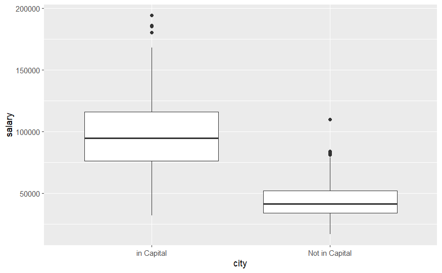

```r
ggplot(salary_raw, mapping = aes(x = city, y = salary)) +
  geom_boxplot()
```

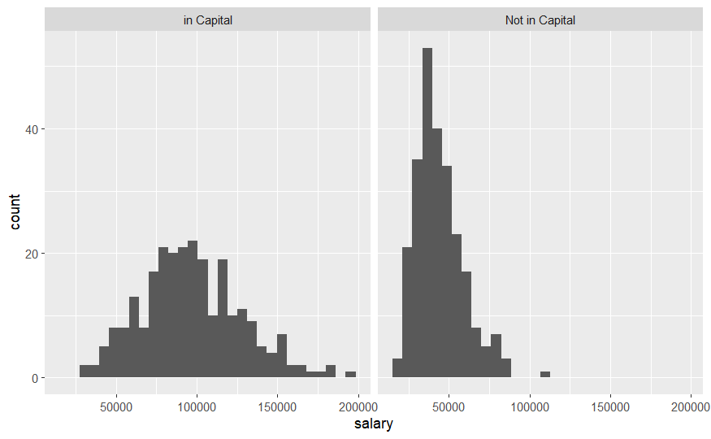

```r
ggplot(salary_raw, mapping = aes(x = salary)) +
  geom_histogram() +
  facet_wrap(~ city)
```

For now, we leave the visualization part for what it is. However, more techniques on visualizing descriptive statistics will be discussed in the next unit.

## Mean

```r
salary_raw %>%
  summarise(mean_salary = mean(salary))
```

| mean_salary |
| --- |
| 70592 |

Can you change the following code such that it calculates not the overall mean salary, but the mean split by living in the capital or not?

```r
salary_raw %>%
  group_by(city) %>%
  summarise(mean_salary = mean(salary))
```

| city | mean_salary |
| --- | --- |
| Not in Capital | 44252 |
| in Capital | 96932 |

## Median

While the mean has to do with the middle value, the median is more about the middle position. To obtain the median of a dataset we must first sort the values in numerical order from smallest to largest. If we have an odd number of values then the median is the unique value which lies in the middle position of our sorted list. If we have an even number of values then the median is the mean of the two values which lie in the middle positions.

```r
salary_raw %>%
  summarise(median_salary = median(salary))
```

| median_salary |
| --- |
| 61500 |

```r
salary_raw %>%
  group_by(city) %>%
  summarise(median_salary = median(salary))
```

| city | median_salary |
| --- | --- |
| Not in Capital | 41500 |
| in Capital | 94500 |

## The mode

The mode is perhaps the most intuitive measure to understand: it is simply the value which occurs the most often in a dataset. An easy way to remember the mode is using the acronym Most-often Occurring Data Element.

What if there is more than one value that appears the most often? In that case we consider each value that occurs the most often as the mode.

The mode is the trickiest value to obtain in R, as there is no function for it to do so. To obtain the mode, we would have to count() how often each value occurs, and then take the value, or values, that occur(s) the most.

```r
salary_raw %>%
  count(salary, sort = TRUE) %>%
  filter(n == max(n))
```

| salary | n |
| --- | --- |
| 36000 | 12 |
| 42000 | 12 |

```r
salary_raw %>%
  group_by(city) %>%
  count(salary, sort = TRUE) %>%
  filter(n == max(n))
```

| city | salary | n |
| --- | --- | --- |
| Not in Capital | 36000 | 12 |
| in Capital | 85000 | 7 |

Now you might wonder why we would want to have multiple ways of computing an average value. After all why can’t we just pick one and stick with it? As it turns out, they each have distinct properties that makes them appropriate for different scenarios. Let’s look again at our example.

Did you notice that the mean and the median salaries are very different from each other? Look at the following histogram, where the mean and median are highlighted :

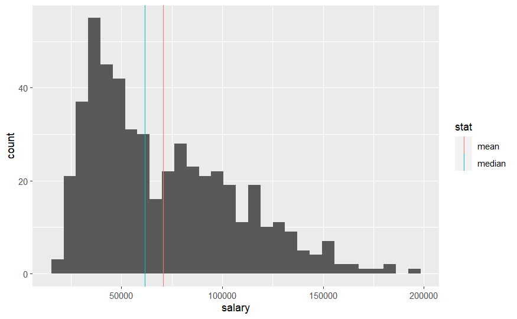

```r
ggplot(salary_raw, mapping = aes(x = salary)) +
  geom_histogram() +
  geom_vline(data = salary_raw %>%
               summarize(mean = mean(salary), median = median(salary)) %>%
               gather(stat, value, mean, median),
             mapping = aes(xintercept = value, colour = stat))
```

The mean lies much higher than the median. This is often the case when looking at salary data: because there are a few people that are earning much higher salaries than most people, the mean will be shifted to the right (it will be higher). You could argue that looking at the median in a case like this provides a better representation of the central tendency of the data than the mean.

# Categorical data

There are however two other ways in which we can describe ordinal and nominal data. The first one is frequency counts, which will reveal to us how many observations we have on each category.

Getting frequency tables in R is simple:

```r
salary_raw %>%
  count(city)
```

| city | n |
| --- | --- |
| Not in Capital | 250 |
| in Capital | 250 |

If this code looks familiar, this makes sense, because we used a very similar approach to calculate the mode for the salaries. Remember that the mode simply counts which value appears the most often in the data?

This means that we can use this statistic also for nominal and ordinal data. Simply put, the mode of a categorical column is the category that appears most often. Can you write code that reveals to us which category is the mode in this data?

# Descriptive statistics

## Spread

For this, the most straightforward measures to consider are the minimum, maximum, and range of the data. Knowing the minimum and maximum of the data is useful because it can help you determine whether all the values in your data are actually possible.

The range, further, is simply the distance between the minimum value of the data, and the maximum value of the data.

Can you calculate the minimum, maximum, and range of salary, and give the output in a tibble?

```r
salary_raw %>%
  summarise(min_salary = min(salary),
            max_salary = max(salary),
            range_salary = max_salary - min_salary)
```

| min_salary | max_salary | range_salary |
| --- | --- | --- |
| 17000 | 194000 | 177000 |

## Quartiles and interquartile range

In R, we can obtain the quartiles using the `quantile()` function. Have a look at the following code:

```r
salary_raw %>%
  summarise(q1 = quantile(salary, 0.25),
            q2 = quantile(salary, 0.5),
            q3 = quantile(salary, 0.75))
```

| q1 | q2 | q3 |
| --- | --- | --- |
| 40000 | 61500 | 95000 |

Before reading on, can you describe in your own words what the quantile() function does?

Say we want to split the data according to the first quartile. Recall that the first quartile splits the data at 25%, so that the lowest 25% of observations are split from the highest 75%. The quantile() function finds for the specified percentage point, in this case .25, the value in the data for which this happens. We find that in the salary data, a salary of 40’000 EXF lies on Q1.

There are two things to note.

- For statistical reasons, the split is expressed as a probability. So instead of saying 25, we type 0.25.
- Note that the function is called quantiles, not quartiles. This is because the function is not limited to the quartiles, but it can split the data by any value.

## The variance

As before, you don’t ever have to calculate variance and standard deviation by hand. Instead we can use R’s built-in functions:

```r
salary_raw %>%
  group_by(city) %>%
  summarise(variance_salary = var(salary),
            sd_salary = sd(salary))
```

| city | variance_salary | sd_salary |
| --- | --- | --- |
| Not in Capital | 217683229 | 14754.09 |
| in Capital | 960071663 | 30985.02 |

# Select the right graph!

## Graph for 1 variable

### Graph for 1 numerical continuous variable

Question : What is the distribution of member weights at week 0, when they register to the Fitness Club ?

Recommendation 1 : Do a Histogram

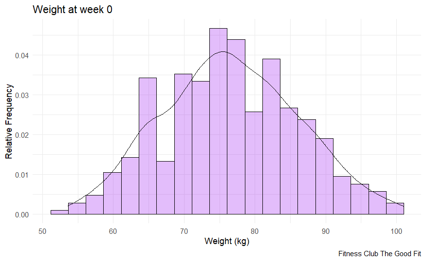

```r
fitness_members_raw %>% ggplot(aes(x = weight)) +
  geom_histogram(aes(y = ..density..),
                 bins = 20,
                 colour = "black",
                 fill = "purple",
                 alpha = 0.3) +
  geom_density() +
  labs(title = "Weight at week 0",
       caption = "Fitness Club The Good Fit",
       x = "Weight (kg)",
       y = "Relative Frequency") +
  theme_minimal()
```